# README: SARS-CoV-2 sequence submission process

Arianna Smith and Mandy Waters

June 2022

### Goals

Provide a detailed overview of SARS-CoV-2 submissions to GISAID, NCBI BioSample, NCBI SRA, and NCBI GenBank. This document will take CDPHE colleagues through initial set up on a GCP VM running Ubuntu 18.04, process/pipeline flow, and scripts developed to automate metadata genereation. Scripts are availble on the CDPHE [Github](https://github.com/CDPHE/seq-submission-metadata-R). This section will cover the following items:

1. Getting set up with software and accounts (GISAID and NCBI)
2. High level overview and process
3. General information
4. Submission steps
5. Detailed code

### Set up and software

#### Overview

Users will need to create accounts with GISAID and NCBI, install software, and complete some preliminary steps before running the sequence submission pipeline. Please follow all instructions in subsequent tabs to get set up.

#### GISAID account

Navigate to GISAID’s [registration page](https://www.gisaid.org/registration/register/). Click on the ‘register’ button on the bottom right corner of the page. Fill in with your personal and CDPHE info:

Institution: Colorado Department of Public Health and Environment

Department: Microbiology

Address: 8100 E Lowry Blvd Denver CO 80230

email: CDPHE email

They will send you an email to confirm your registration with a link you need to click on. Then you will get another email confirming your successful registration.

#### NCBI account

NCBI’s login method uses your gmail (CDPHE email) to sign in and authenticate. Make sure the keychain for your browser is for your CDPHE email otherwise it will error out. Follow the instructions given by NCBI to create a new account. NCBI will send you a confirmation email once they’ve processed your request.

Navigate to NCBI’s [registration page](https://account.ncbi.nlm.nih.gov/signup/).

Institution: Colorado Department of Public Health and Environment

Department: Microbiology

Address: 8100 E Lowry Blvd Denver CO 80230

email: CDPHE email

back-up email: personal email

#### Software

Programs to download/install on your VM for the submission process:

1. [Visual Studio Code](https://code.visualstudio.com/download): editing text files.
2. [Seqtk](https://github.com/lh3/seqtk): parsing and editing fasta files.
3. [SeqKit](https://bioinf.shenwei.me/seqkit/download/): parsing and editing fasta files.
4. [VADR](https://github.com/StaPH-B/staphb_toolkit): is part of the staphb-tk that you installed in the Getting Started document.
5. [MAFFT](https://mafft.cbrc.jp/alignment/software/linux.html): MSA. Molly’s version of indel_finder as of Sept 3, 2021 runs MAFFT pairwise for each sample in your batch, but might be good to have a local copy.
6. [IGV](https://software.broadinstitute.org/software/igv/download): checking read coverage.
7. [Indel_finder.py](https://github.com/CDPHE/sars-cov-2_indel_finder): is on the CDPHE github page.
8. Samtools: working and indexing alignment (bam) files.

```bash
# I have conda installed and therefore was able to install samtools with conda
conda install -c bioconda samtools
```

9. Aspera Connect Ascp:

```bash
gsutil cp -r gs://laura-sandbox/aspera-connect/
# Then you can find ascp in aspera/connect/bin.
# You might need to make the ascp file executable by running:
chmod +x aspera/connect/bin/ascp
```

10. [Aliview](https://ormbunkar.se/aliview/#DOWNLOAD) - review MSA. After install, you can open ‘aliview’ by just typing aliview on your VM terminal.
11. rename_fasta.py: might be good to have, but Molly’s modifications to indel_finder as of Sept 3, 2021 takes in multi-fasta, so this script isn’t needed. Can be accessed using:

```bash
gsutil cp gs://laura-terra/rename_fasta.py
```

### General Information

Special call out to Laura Bankers for most of the content below.

Overview: All sequencing data, intermediate files, alignments (bam files), and assemblies are stored in the google bucket gs://covid_terra in the SNP Linux project on GCP. Inside that bucket, there is a directory for each sequencing run, and inside that directory are all of the raw data and necessary files for every sample sequenced on that run. Sequencing run directories are named based on the platform + run id number. Those beginning with COVSEQ_ are paired-end Illumina Miseq runs, those beginning with COVMIN_ are Oxford Nanopore GridION runs, NEXSEQ_ are single-end NextSeq runs, and COVARC are archived samples from earlier in the pandemic that we are now going back to and are sequenced on either MiSeq or GridION. The numbers after the underscore are the run id numbers (e.g. COVMIN_0009 is nanopore run 0009).

Extra information:

Early COVMIN runs were re-analyzed due to workflow updates. The final results for these runs are in “terra_outputs_rr” (be sure to use files in the _rr directories in these cases). The underlying directory structure in the _rr directory is the same as the other output directories

NCBI BioSample only lets you submit up to 1000 samples at a time – So I tend to just maintain batch numbers of up to 1000 sample throughout the entire process. This is generally 2 NEXSEQ runs or 10 COVMIN runs in one batch.

GenBank only allows you to select a single sequencing technology for an entire submission, so only include a single sequencing platform in a given batch (i.e. up to 1000 sample from only Illumina MiSeq runs).

### Submission steps

The following tabs contain general descriptions of submission steps. Detailed code for running scripts and generating files will be written below.

There is a .docx file format for tracking each submission- this is where you will put information such as submission id’s and dates. Update this sheet as you move through the submission process. When you are finished, make sure you save the file in your VM so it can be referenced in the future if needed.

#### Getting ready

The [submission spreadsheet](https://docs.google.com/spreadsheets/d/15QoZJeowBrGx2yMYv79ZXjvIQl8lqIZJb4esyY4VX-o/edit#gid=572846276) contains a tab of NOT_submitted runs. In this file, you will put your name/initials in the ‘Note’ column on the runs you are going to submit. This ensures that there aren’t multiple people working on the same runs. They are ready for submission once the ‘Added submission metadata’ column says complete and the row is not highlighted. The ‘Other notes’ column will contain information such as missing collection dates.

You will need to download a few files to get started. They are:

1. The completed submissions file.
   - Navigate to the [Google sheet](https://docs.google.com/spreadsheets/d/15QoZJeowBrGx2yMYv79ZXjvIQl8lqIZJb4esyY4VX-o/edit#gid=572846276) - if you can’t reach this site then one of the current contributors with edit access to share the file with you.
   - Download the COMPLETED_submissions tab as a .tsv file.
2. The reruns file.
   - Navigate to the [Google sheet](https://docs.google.com/spreadsheets/d/1PtaHHa8iuqM6fNGTSkHiinxc5poQnVt1Ti67yLSVQ6c/edit#gid=0) - if you can’t reach this site then one of the current contributors with edit access to share the file with you.
   - Download the re-run_samples tab as a .tsv file.
3. The result(s) file.
   - Navigate to the [shared drive](https://drive.google.com/drive/folders/0ADccwVQdrg3VUk9PVA). Then go to the folder COVID -> Data Sharing -> Sequencing Run Results -> your sequencing technology folder
   - For each of the runs you are submitting in your batch, go to its folder and download the results_*.tsv file.
   - If there are missing collection dates, there will be a file for them in that folder. Make sure that the samples have that information in the results file, and add them if needed.

Submissions to the databases occur in a specific order: GISAID, BioSample, SRA, Genbank. You will download files from each database after successful submission, which you will need to use to create the files for the next database.

#### GISAID

The metadata file needed will be generated by the gisaid_metadata_formatting.py script. The fasta file will be generated by steps outlined in the detailed code below.

1. Login to your [GISAID account](https://www.gisaid.org/). Go to the EpiCoV tab, click Upload, and then elect Batch upload. You can ignore the CLI3 popup.
2. You will submit the metadata and fasta files. Under confirmation options, select “Notify me only about NOT PREVIOUSLY REPORTED FRAMESHIFTS AND/OR SPIKE TRUNCATIONS in this submission for reconfirmation of affected sequences.” If you leave it as the default option, it will notify you of every frameshift found (which will be a lot).
3. Once your sequences have been processed, you will receive an email from GISAID. If they find any errors, they will send you another email asking you to review them. You can access their xlsx file under the ‘My Unreleased’ tab. It will contain the sequences and comments from the GISAID team.
- Write out a new fasta file with the consensus sequences that were rejected (corrected and unchanged sequences if coverage supports the nucleotide seq) and replace this new fasta in the upload page on GISAID. You can give further details on corrections or confirmations by clicking the ‘Contact Curation’ option.
4. Once all sequences have been processed, you will go to the ‘Search’ tab. In the Virus Name field, write ‘hCoV-19/USA/CO-CDPHE’. In the first ‘Submission’ field, select your initial submission date. Click the upper check mark to select all samples, click ‘Download’, and select ‘Sequencing technology metadata’. This will give you the hCoV file needed for BioSample.

Also- if you notice that the submission date listed is one day ahead of when you submitted it, remember that they are based in Germany and ahead of us :)

#### GISAID Intermission

While you are waiting for GISAID to respond, there are a few steps you will want to perform. They include: downloading fastq files for SRA submission, running VADR, and pulling the .bam files for IGV. These steps can take a while, so be sure to start them early.

#### BioSample

The metadata file needed will be generated by the ncbi_biosample_metadata_formatting.py script.

Go to the BioSample [submission portal](https://submit.ncbi.nlm.nih.gov/subs/biosample/) and select ‘New Submission’. There will be a few sections to fill out.

##### Submitter

Fill out the submitter info with your state email as the primary email and fill out institutional information as follows:

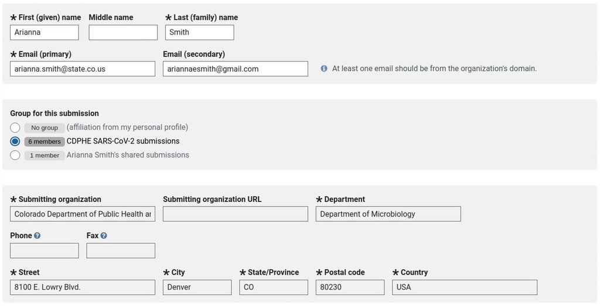

##### General Info

Select ‘Release immediately following processing’ and ‘Batch/Multiple BioSamples’.

##### Sample Type

Select ‘SARS-CoV-2: clinical or host-associated’- it is the first option on the left under All Packages.

##### Attributes

Select ‘Upload a file’ and upload the ncbi_biosample_submission_*metadata.tsv file.

##### Review and Submit

Make sure everything is correct before finalizing submission.

Once BioSample is finished processing, you will receive an email from them with a file named BioSampleObjects.txt. Download and move to your metadata folder.

#### SRA

You need to have the raw fastq files downloaded to your sequence_data folder. The ncbi_sra_metadata_formatting.py script will generate the metadata file.

Go to the SRA [submission portal](https://submit.ncbi.nlm.nih.gov/subs/sra/) and select ‘New Submission’. There will be a few sections to fill out.

##### Submitter

Fill out as in the BioSample submission.

##### General Info

Select ‘Yes’ for an already registered BioProject and write PRJNA686984 in the existing BioProject field. Select ‘Yes’ for an already registered BioSample. Select ‘Release immediately following processing’.

##### SRA Metadata

Upload the ncbi_sra_submission_*metadata.tsv file.

##### Files

Select ‘FTP or Aspera Command Line file preload’.

Read the Aspera Commandline instructions tab, and download the key file to your VM.

Go back to your VM commandline window, cd into the directory containing your fastq files and run:

```bash
# SRA will provide the rest of subasp@upload.ncbi.nlm.nih.gov:upload on your upload page
# This is mine as an example
/home/arianna_smith/aspera-connect/connect/bin/ascp -i /home/arianna_smith/aspera.openssh -d ${cur_wd}/sequence_data subasp@upload.ncbi.nlm.nih.gov:uploads/arianna.smith_state.co.us_Q6Oajo2Y
```

Once you see that the upload has completed in your command line window, go back to your submission and click the ‘Select preload folder’ button. Select the folder containing your fastq files and then ‘Use selected folder’ (make sure you refresh until it lists the same number of files that you uploaded).

- Important- if you are submitting another batch before your previous batch has been processed by SRA, you will need to change your sequence_data folder name, e.g. ${cur_wd}/sequence_data2. Make sure to change the name in the command to upload the fastq files as well.

##### Review and Submit

Make sure everything is correct before finalizing submission.

Once SRA is finished processing, you will receive an email from them. Go to the SRA [submission portal](https://submit.ncbi.nlm.nih.gov/subs/sra/) and find your submission. Download metadata file with SRA accessions and move it (metadata-*-processed-ok.tsv) into your metadata folder.

#### GenBank

The ncbi_genbank_metadata_formatting.py script will generate the metadata file.

Go to the GenBank [submission portal](https://submit.ncbi.nlm.nih.gov/subs/genbank/) and select ‘New Submission’. There will be a few sections to fill out.

##### Submission Type

Select ‘SARS-CoV-2, Influenza, Norovirus, or Dengue virus’ and ‘SARS-CoV-2’. Under Submission Title, I like to write the batch number I’m submitting, e.g. as_batch10.

##### Submitter

Fill out as in the BioSample and SRA submissions.

##### Sequencing Technology

###### NEXSEQ

Method: Illumina

Assembly state: Assembled sequences

Assembly information:

Assembly program: BWA, Version or date: 0.7.17-r1188

Assembly program: iVar, Version or date: 1.3.1

###### COVMIN

Method: Other, Oxford Nanopore

Assembly state: Assembled sequences

Assembly information:

Assembly program: Arctic MinION, Version or date: JAN-2020

##### Sequences

Select ‘Release immediately following processing’ and upload the batch*_ncbi_genbank_corrected_proj.fasta file.

##### Sequence Processing

Select ‘Yes’ to remove errors.

##### Source Info

Select ‘None of these’ for naming convention.

##### Source Modifiers

Upload the ncbi_genbank_submission_*metadata.tsv file.

##### References

Under Sequence Authors, put Laura Bankers, Haikel N. Bogale, Molly C. Hetherington-Rauth, Diana Ir, Shannon R. Matzinger, Alexandria Rossheim, Arianna Smith. You have to manually put these in the first time and then you can select and apply this list for later submissions.

Select ‘Unpublished’ and leave the rest blank.

##### Review and Submit

Make sure everything is correct before finalizing submission.

When GenBank is finished processing, they will email you with a file named either seqids.txt or accessions.txt. Download this file and move it to the metadata folder.

#### Completed Submission

The submission_completed_metadata.py script will generate a COMPLETED_*.tsv file. You will copy and paste this to the completed tab on the [submission spreadsheet](https://docs.google.com/spreadsheets/d/15QoZJeowBrGx2yMYv79ZXjvIQl8lqIZJb4esyY4VX-o/edit#gid=572846276). Make sure to drag down the id numbers in the first column. In the NOT_submitted tab, add ‘-complete’ after your name/initials for each run in the finished batch.

### Detailed Code

I run all my bash code in a conda environment to make sure everything runs smoothly with the different python packages needed. The code is basically identical for COVMIN and NEXSEQ and COVMIN runs, with just a few differences.

#### COVMIN

```bash
# I make a new directory for each batch of submissions
# Set unix/linux variable path for wd and batch - so can reuse code across projects
conda activate
cur_wd="/home/arianna_smith/batch1_submit"
batch="batch1"

# cd into cur_wd and make directories
mkdir download_fasta # download and work on files fasta files for submissions
mkdir sequence_data # download the fastq files for SRA
mkdir metadata # download and create all metadata files for all submission sites

# In cur_wd make a file called project_list.txt that lists the projects to be submitted - with one project per line (I used vim to add, but users can use text editor if preferred)

# Here I list batch numbers and associated runs so it's easier to keep track of multiple batches being submitted at once

# Pull metadata from Google Drive - pull results*.tsv files for all projects into 'metadata' dir

# Downloaded updated re-run sample file from Google Drive and rename
cd $cur_wd/metadata
mv List_of_bad_runs_and_waste_water_samples\ -\ re-run_samples.tsv rerun_samples_$(date +%d%b%Y).tsv

# Download completed sample list from Google Drive and rename
mv SUBMISSION_records*.tsv completed_submissions_$(date +%d%b%Y).tsv

#################################################################################################################

# generate gisaid metadata- I write these files to the 'metadata' dir
python3 /home/arianna_smith/seq-submission-metadata-R/gisaid_metadata_formatting.py -m ${cur_wd}/metadata -s ariannaesmith -f ${batch}_gisaid_inital_upload.fa -t "Oxford Nanopore GridION" -r ${cur_wd}/metadata/rerun_samples_*.tsv -c ${cur_wd}/metadata/completed_submissions_*.tsv

# Get list of files with >= 50% coverage in 'metadata'
awk -F/ 'NR>1 {print $3}' gisaid_submission_*_metadata.csv > fasta_headers_50cov.txt
sed -i '1s/^/sample_name\n/' fasta_headers_50cov.txt

# pull consensus fastas to 'download_fasta' dir
cd $cur_wd/download_fasta
while read name; do gsutil -m cp -r gs://covid_terra/${name}/terra_outputs/assemblies/*_consensus_renamed.fa .; done < ${cur_wd}/project_list.txt

# Concat all downloaded fastas in 'download_fasta' dir
cat *_consensus_renamed.fa > raw_concat.fa

# Pull fastas with > 50% coverage
seqtk subseq raw_concat.fa ${cur_wd}/metadata/fasta_headers_50cov.txt > subset_50cov.fa

# Check length of subset_50cov.fa against the metadata.  If metadata data file is N+1 then you can delete the original *_consensus_renamed.fa files
grep -c "^>" subset_50cov.fa
wc -l $cur_wd/metadata/gisaid_submission_*_metadata.csv

# Delete the original & individ files
rm *_consensus_renamed.fa

# Run indel finder
conda activate indel_finder_env
/home/arianna_smith/sars-cov-2_indel_finder/indel_finder_aligner.py -i ${cur_wd}/download_fasta/subset_50cov.fa -o ${cur_wd}/download_fasta --ref_path /home/arianna_smith/ref_seq/reference.fasta --prefix ${batch}
conda deactivate

# Rename seq names with GISAID format in 'download_fasta' dir
awk -F, 'FNR==NR {f2[$1]=$2;next} $2 in f2 {$2=f2[$2]}1' ${cur_wd}/metadata/fasta_rename_accession_to_gisaid_id.csv FS='>' OFS='>' ${cur_wd}/download_fasta/${batch}.alignment.fasta > post_indel_concat_gisaid_format.fa
cp post_indel_concat_gisaid_format.fa ${batch}_gisaid_initial_upload.fa
cp post_indel_concat_gisaid_format.fa ${batch}_gisaid_reupload_all_seqs.fa

# Files uploaded to GISAID
# metadata: gisaid_submission_*_metadata.csv
# fasta: batch1_gisaid_initial_upload.fa

#################################################################################################################

# Following steps to do while waiting for GISAID to respond

# Pull seqs for SRA - in sequence_data dir.  Start this early as this step takes a long time
# NOTE: This code is specific for Nanopore
# I open a new terminal window so I can download fastq files and run VADR at the same time
conda activate
cur_wd="/home/arianna_smith/batch1_submit"
batch="batch1"
while read name
do
python3 /home/arianna_smith/seq-submission-metadata-R/get_cat_gzip_fastq.py $cur_wd/metadata/filtered_results_subset_metadata.tsv $name
done < ${cur_wd}/project_list.txt

# Run in original terminal window
# Removing dashes from the MSA from indel finder as VADR doesn't accept dashes
sed '/^>/! s/-//g' post_indel_concat_gisaid_format.fa > post_indel_concat_gisaid_format_nodash.fa

# Run VADR 1.3 on entire dataset
docker run --rm=True -v $PWD:/data -u $(id -u):$(id -g) staphb/vadr:1.3 v-annotate.pl --split --cpu 8 --glsearch -s -r --nomisc --mkey sarscov2 --lowsim5seq 2 --lowsim3seq 2 --alt_fail lowscore,insertnn,deletinn post_indel_concat_gisaid_format_nodash.fa vadr_run

# Pulling samples for IGV in vadr_run
sed 's/hCoV-19\/USA\/CO-CDPHE-//g' $cur_wd/download_fasta/vadr_run/vadr_run.vadr.fail.list > $cur_wd/metadata/accessions_failed_to_pull.csv
sed -i -e 's/\/202.*//g' $cur_wd/metadata/accessions_failed_to_pull.csv
while read name; do grep $name ${cur_wd}/metadata/results*.tsv >> $cur_wd/metadata/failed_to_pull_bam_files.txt; done < $cur_wd/metadata/accessions_failed_to_pull.csv

# try one of the following lines (first is most likely to be correct)
grep -oP 'results_\KCOVMIN_[[:alnum:]]*|tsv:\K[[:digit:]]{10}' $cur_wd/metadata/failed_to_pull_bam_files.txt | paste - - > $cur_wd/metadata/project_accessions_failed.txt
grep -oP 'COVMIN[[:alnum:]]*|CDPHE-\K[[:digit:]]{10}' $cur_wd/metadata/failed_to_pull_bam_files.txt | paste - - > $cur_wd/metadata/project_accessions_failed.txt

cat $cur_wd/metadata/project_accessions_failed.txt

while read project acc; do gsutil cp gs://covid_terra/${project}/terra_outputs/alignments/${acc}*.bam .; done < $cur_wd/metadata/project_accessions_failed.txt
for i in *.bam; do samtools index $i; done

#################################################################################################################

# check GISAID rejected samples in Alivew and IGV
# Edit file batch1_gisaid_reupload_all_seqs.fa

# Add in accessions from the unreleased metadata file - I use VIM to write file: gisaid_accessions_failed.txt

# Pulling those sequences to reupload
seqkit grep -n -f gisaid_accessions_failed.txt ${batch}_gisaid_reupload_all_seqs.fa -o ${batch}_gisaid_reupload_seqs.fa

# reupload to GISAID
# batch19_gisaid_reupload_seqs.fa

# Download GISAID (from search tab on GISAID): gisaid_hcov-19_*.tsv

#################################################################################################################


# Once GISAID is processed, create metadata table for Biosample
python3 /home/arianna_smith/seq-submission-metadata-R/ncbi_biosample_metadata_formatting.py -m ${cur_wd}/metadata
# Check script for warnings (e.g. missing GISAID accession id)

# Submit Biosample

#################################################################################################################

# download file BioSampleObjects.txt sent in email from NCBI to 'metadata' dir

# Create metadata for SRA
python3 /home/arianna_smith/seq-submission-metadata-R/ncbi_sra_metadata_formatting.py -p ${cur_wd}/metadata -t "Oxford Nanopore GridION"

# get files to keep for upload to SRA in 'metadata' dir
cut -f 13 $cur_wd/metadata/ncbi_sra_submission_*metadata.tsv | sed 's/"//g' | grep -v '^file' > $cur_wd/metadata/fastqs_to_keep.tsv

# Deleting files don't need to upload in 'sequence_data' dir
cd $cur_wd/sequence_data
for dir in */; do
    cd $dir
    for i in *fastq.gz; do
        if ! grep -qxFe "$i" ${cur_wd}/metadata/fastqs_to_keep.tsv; then
            echo "Deleting: $i"
            rm "$i"
        fi
    cd $cur_wd/sequence_data
    done
done

# Upload to SRA
# Bioproject PRJNA686984
# metadata
/home/arianna_smith/aspera-connect/connect/bin/ascp -i /home/arianna_smith/aspera.openssh -d ${cur_wd}/sequence_data subasp@upload.ncbi.nlm.nih.gov:uploads/arianna.smith_state.co.us_Q6Oajo2Y

#################################################################################################################

# Download SRA metadata (from submissions tab on NCBI): metadata-10434424-processed-ok.tsv

# Create NCBI metadata sheet
python3 /home/arianna_smith/seq-submission-metadata-R/ncbi_genbank_metadata_formatting.py -p ${cur_wd}/metadata -t "Oxford Nanopore GridION"

# Getting fasta file ready for NCBI in 'download_fasta' dir
cd $cur_wd/download_fasta
sed '/^>/! s/-//g' ${batch}_gisaid_reupload_all_seqs.fa > ${batch}_ncbi_genbank_corrected.fasta
awk '{if (substr($1, 1, 1)==">") print $0" [bioproject=PRJNA686984]"; else print $0}' ${batch}_ncbi_genbank_corrected.fasta > ${batch}_ncbi_genbank_corrected_proj.fasta

# files uploaded to GenBank
# metadata: ncbi_genbank_submission_*_metadata.tsv
# fasta: batch1_ncbi_genbank_corrected_proj.fasta

#################################################################################################################

# Download accessions.txt from NCBI email and move to 'metadata' dir

# create final submission metadata
python3 /home/arianna_smith/seq-submission-metadata-R/submission_completed_metadata.py -p ${cur_wd}/metadata -s ariannaesmith
```

#### NEXSEQ

```bash
# I make a new directory for each batch of submissions
# Set unix/linux variable path for wd and batch - so can reuse code across projects
conda activate
cur_wd="/home/arianna_smith/batch2_submit"
batch="batch2"

# cd into cur_wd and make directories
mkdir download_fasta
mkdir sequence_data
mkdir metadata

# In cur_wd make a file called project_list.txt that lists the projects to be submitted - with one project per line (I used vim to add, but users can use text editor if preferred)

# Here I list batch numbers and associated runs so it's easier to keep track of multiple batches being submitted at once

# Pull metadata from Google Drive - pull results*.tsv files for all projects into 'metadata' dir

# Downloaded updated re-run sample file from Google Drive and rename
cd $cur_wd/metadata
mv List_of_bad_runs_and_waste_water_samples\ -\ re-run_samples.tsv rerun_samples_$(date +%d%b%Y).tsv

# Download completed sample list from Google Drive and rename
mv SUBMISSION_records*.tsv completed_submissions_$(date +%d%b%Y).tsv

#################################################################################################################

# Create metadata table for GISAID first
python3 /home/arianna_smith/seq-submission-metadata-R/gisaid_metadata_formatting.py -m ${cur_wd}/metadata -s ariannaesmith -f ${batch}_gisaid_inital_upload.fa -t "Illumina NextSeq" -r ${cur_wd}/metadata/rerun_samples_*.tsv -c ${cur_wd}/metadata/completed_submissions_*.tsv

# Get list of files with >= 50% coverage
awk -F/ 'NR>1 {print $3}' gisaid_submission_*_metadata.csv > fasta_headers_50cov.txt
sed -i '1s/^/sample_name\n/' fasta_headers_50cov.txt

# pull consensus fastas to 'download_fasta' dir
cd $cur_wd/download_fasta
while read name; do gsutil -m cp -r gs://covid_terra/${name}/terra_outputs/assemblies/*_consensus_renamed.fa .; done < ${cur_wd}/project_list.txt

# Concat all downloaded fastas in 'download_fasta' dir
cat *_consensus_renamed.fa > raw_concat.fa

# Pull fastas with > 50% coverage
seqtk subseq raw_concat.fa ${cur_wd}/metadata/fasta_headers_50cov.txt > subset_50cov.fa

# Check length of subset_50cov.fa against the metadata.  If metadata data file is N+1 then you can delete the original *_consensus_renamed.fa
grep -c "^>" subset_50cov.fa
wc -l $cur_wd/metadata/gisaid_submission_*_metadata.csv

# Delete the original & individ files
rm *_consensus_renamed.fa

# Run indel finder
conda activate indel_finder_env
/home/arianna_smith/sars-cov-2_indel_finder/indel_finder_aligner.py -i ${cur_wd}/download_fasta/subset_50cov.fa -o ${cur_wd}/download_fasta --ref_path /home/arianna_smith/ref_seq/reference.fasta --prefix ${batch}
conda deactivate

# Rename seq names with GISAID format
awk -F, 'FNR==NR {f2[$1]=$2;next} $2 in f2 {$2=f2[$2]}1' ${cur_wd}/metadata/fasta_rename_accession_to_gisaid_id.csv FS='>' OFS='>' ${cur_wd}/download_fasta/${batch}.alignment.fasta > post_indel_concat_gisaid_format.fa
cp post_indel_concat_gisaid_format.fa ${batch}_gisaid_initial_upload.fa
cp post_indel_concat_gisaid_format.fa ${batch}_gisaid_reupload_all_seqs.fa

# Files uploaded to GISAID
# metadata: gisaid_submission_*_metadata.csv
# fasta: batch2_gisaid_initial_upload.fa

#################################################################################################################

# Following steps to do while waiting for GISAID to respond

# Pull seqs for SRA - in sequence_data dir.
# WARNING: this code is specific for NEXSEQ
cd $cur_wd/sequence_data
while read name
do
gsutil -m cp gs://covid_terra/${name}/fastq_files/*fastq.gz .
done < ${cur_wd}/project_list.txt

# Removing dashes from the MSA from indel finder as VADR doesn't accept dashes
cd $cur_wd/download_fasta
sed '/^>/! s/-//g' post_indel_concat_gisaid_format.fa > post_indel_concat_gisaid_format_nodash.fa

# Run VADR 1.3 on entire dataset in 'download_fasta' dir
docker run --rm=True -v $PWD:/data -u $(id -u):$(id -g) staphb/vadr:1.3 v-annotate.pl --split --cpu 8 --glsearch -s -r --nomisc --mkey sarscov2 --lowsim5seq 2 --lowsim3seq 2 --alt_fail lowscore,insertnn,deletinn post_indel_concat_gisaid_format_nodash.fa vadr_run

# Pulling samples for IGV in vadr_run
sed 's/hCoV-19\/USA\/CO-CDPHE-//g' $cur_wd/download_fasta/vadr_run/vadr_run.vadr.fail.list > $cur_wd/metadata/accessions_failed_to_pull.csv
sed -i -e 's/\/202.*//g' $cur_wd/metadata/accessions_failed_to_pull.csv
while read name; do grep $name ${cur_wd}/metadata/results*.tsv >> $cur_wd/metadata/failed_to_pull_bam_files.txt; done < $cur_wd/metadata/accessions_failed_to_pull.csv

# try one of the following lines (third is most likely to be correct)
grep -oP 'results_\KNEXSEQ_[[:alnum:]]*|tsv:\K[[:digit:]]{10}' $cur_wd/metadata/failed_to_pull_bam_files.txt | paste - - > $cur_wd/metadata/project_accessions_failed.txt
grep -oP 'NEXSEQ_[[:alnum:]]*|CDPHE-\K[[:digit:]]{10}' $cur_wd/metadata/failed_to_pull_bam_files.txt | paste - - > $cur_wd/metadata/project_accessions_failed.txt

# try
grep -oP 'NEXSEQ_[[:alnum:]]*|[[:digit:]]{10}' $cur_wd/metadata/failed_to_pull_bam_files.txt | paste - - > $cur_wd/metadata/project_accessions_failed.txt

cat $cur_wd/metadata/project_accessions_failed.txt

while read project acc; do gsutil cp gs://covid_terra/${project}/terra_outputs/alignments/${acc}*.bam .; done < $cur_wd/metadata/project_accessions_failed.txt
for i in *.bam; do samtools index $i; done

#################################################################################################################

# check GISAID rejected samples in Alivew and IGV
# Edit file batch2_gisaid_reupload_all_seqs.fa

# Add in accessions from the unreleased metadata file - I use VIM to write file: gisaid_accessions_failed.txt

# Pulling those sequences to reupload
seqkit grep -n -f gisaid_accessions_failed.txt ${batch}_gisaid_reupload_all_seqs.fa -o ${batch}_gisaid_reupload_seqs.fa

# reupload to GISAID
# batch32_gisaid_reupload_seqs.fa

# Download GISAID (from search tab on GISAID): gisaid_hcov-19_*.tsv

#################################################################################################################

# Once GISAID is processed, create metadata table for Biosample
python3 /home/arianna_smith/seq-submission-metadata-R/ncbi_biosample_metadata_formatting.py -m ${cur_wd}/metadata
# Check script for warnings (e.g. missing GISAID accession id)

# Submit Biosample

#################################################################################################################

# Download BioSample data from NCBI email and move to metadata dir
# Once Biosample is processed, proceed to SRA submission

# Create metadata for SRA in 'metadata' dir
python3 /home/arianna_smith/seq-submission-metadata-R/ncbi_sra_metadata_formatting.py -p ${cur_wd}/metadata -t "Illumina NextSeq"

# get files to keep for upload to SRA in 'metadata' dir
cut -f 13 $cur_wd/metadata/ncbi_sra_submission_*metadata.tsv | sed 's/"//g' | grep -v '^file' > $cur_wd/metadata/fastqs_to_keep.tsv


# Deleting files that don't need to upload in 'sequence_data' dir for upload to SRA
cd $cur_wd/sequence_data
for i in *fastq.gz; do
    if ! grep -qxFe "$i" ${cur_wd}/metadata/fastqs_to_keep.tsv; then
        echo "Deleting: $i"
        rm "$i"
    fi
done

# Upload to SRA
# Bioproject PRJNA686984
# metadata: ncbi_sra_submission_*_metadata.tsv
/home/arianna_smith/aspera-connect/connect/bin/ascp -i /home/arianna_smith/aspera.openssh -d ${cur_wd}/sequence_data subasp@upload.ncbi.nlm.nih.gov:uploads/arianna.smith_state.co.us_Q6Oajo2Y

#################################################################################################################

# Download SRA (from submissions tab on NCBI): metadata-10462507-processed-ok.tsv

# Create NCBI metadata sheet written to 'metadata' dir
python3 /home/arianna_smith/seq-submission-metadata-R/ncbi_genbank_metadata_formatting.py -p ${cur_wd}/metadata -t "Illumina NextSeq"

# Getting fasta file ready for NCBI in 'download_fasta' dir
cd $cur_wd/download_fasta
sed '/^>/! s/-//g' ${batch}_gisaid_reupload_all_seqs.fa > ${batch}_ncbi_genbank_corrected.fasta
awk '{if (substr($1, 1, 1)==">") print $0" [bioproject=PRJNA686984]"; else print $0}' ${batch}_ncbi_genbank_corrected.fasta > ${batch}_ncbi_genbank_corrected_proj.fasta

# files uploaded to GenBank
# BWA v0.7.17-r1188
# iVar v1.3.1
# metadata: ncbi_genbank_submission_*_metadata.tsv
# fasta: batch2_ncbi_genbank_corrected_proj.fasta

#################################################################################################################

# Download accessions.txt from NCBI email

# create final submission metadata
python3 /home/arianna_smith/seq-submission-metadata-R/submission_completed_metadata.py -p ${cur_wd}/metadata -s ariannaesmith
```